# R Notebook

`r`r ## Example: Predicting Medical Expenses —- ## Step 2: Exploring and preparing the data —- insurance <- read.csv(.csv, stringsAsFactors = TRUE) str(insurance)

```
'data.frame':   1338 obs. of  7 variables:
 $ age     : int  19 18 28 33 32 31 46 37 37 60 ...
 $ sex     : Factor w/ 2 levels \female\,\male\: 1 2 2 2 2 1 1 1 2 1 ...
 $ bmi     : num  27.9 33.8 33 22.7 28.9 25.7 33.4 27.7 29.8 25.8 ...
 $ children: int  0 1 3 0 0 0 1 3 2 0 ...
 $ smoker  : Factor w/ 2 levels \no\,\yes\: 2 1 1 1 1 1 1 1 1 1 ...
 $ region  : Factor w/ 4 levels \northeast\,\northwest\,..: 4 3 3 2 2 3 3 2 1 2 ...
 $ expenses: num  16885 1726 4449 21984 3867 ...
```

`r`r # summarize the charges variable summary(insurance$expenses)

```
   Min. 1st Qu.  Median    Mean 3rd Qu.    Max.
   1122    4740    9382   13270   16640   63770
```

## ‘expenses’ is our dependent variable. Using linear regression, we will try to predict expenses using all other independent variables.

`r`r # histogram of insurance charges hist(insurance$expenses)

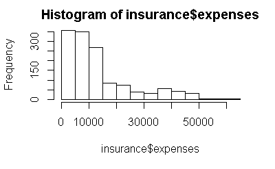

## From the histogram, we see that the distribution of insurance expenses is right-skewed.

`r`r # table of region table(insurance$region)

```
northeast northwest southeast southwest
      324       325       364       325
```

## The data is almost evenly distributed among the four regions.

## We now try to find the linear association between the features by calculating their correlation coefficients with each other in a correlation matrix:

`r`r # exploring relationships among features: correlation matrix cor(insurance[c(, , , )])

```
               age        bmi   children   expenses
age      1.0000000 0.10934101 0.04246900 0.29900819
bmi      0.1093410 1.00000000 0.01264471 0.19857626
children 0.0424690 0.01264471 1.00000000 0.06799823
expenses 0.2990082 0.19857626 0.06799823 1.00000000
```

`r`r # visualing relationships among features: scatterplot matrix pairs(insurance[c(, , , )])

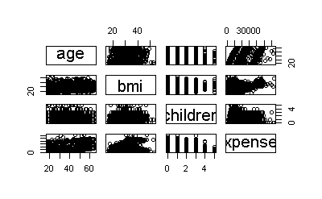

## There appears to be a somewhat linear relationship between ‘age’ and ‘expenses’

`r`r # more informative scatterplot matrix library(psych) pairs.panels(insurance[c(, , , )])

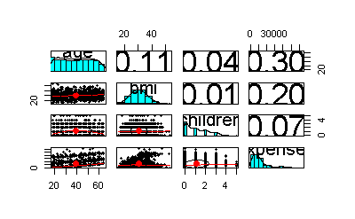

## The correlation ellipse between bmi and children is almost a perfectly round oval. This indicates very weak correlation between them.

## The loess curve for age and children is an upside-down U, peaking around middle age. This is a non-linear relationship indicating that middle-aged people have the most number of children on the insuarance plan.

`r`r ## Step 3: Training a model on the data —- ins_model <- lm(expenses ~ age + children + bmi + sex + smoker + region, data = insurance) ins_model <- lm(expenses ~ ., data = insurance) # this is equivalent to above # see the estimated beta coefficients ins_model

```
Call:
lm(formula = expenses ~ ., data = insurance)

Coefficients:
    (Intercept)              age          sexmale              bmi         children
       -11941.6            256.8           -131.4            339.3            475.7
      smokeryes  regionnorthwest  regionsoutheast  regionsouthwest
        23847.5           -352.8          -1035.6           -959.3
```

## The beta coefficients for each feature indicate the estimated increase in expenses for an increase of one unit in the feature. eg. For every addition of a smoking individual, expenses increase by $23847.5

`r`r ## Step 4: Evaluating model performance —- # see more detail about the estimated beta coefficients summary(ins_model)

```
Call:
lm(formula = expenses ~ ., data = insurance)

Residuals:
     Min       1Q   Median       3Q      Max
-11302.7  -2850.9   -979.6   1383.9  29981.7

Coefficients:
                Estimate Std. Error t value Pr(>|t|)
(Intercept)     -11941.6      987.8 -12.089  < 2e-16 ***
age                256.8       11.9  21.586  < 2e-16 ***
sexmale           -131.3      332.9  -0.395 0.693255
bmi                339.3       28.6  11.864  < 2e-16 ***
children           475.7      137.8   3.452 0.000574 ***
smokeryes        23847.5      413.1  57.723  < 2e-16 ***
regionnorthwest   -352.8      476.3  -0.741 0.458976
regionsoutheast  -1035.6      478.7  -2.163 0.030685 *
regionsouthwest   -959.3      477.9  -2.007 0.044921 *
---
Signif. codes:  0 â***â 0.001 â**â 0.01 â*â 0.05 â.â 0.1 â â 1

Residual standard error: 6062 on 1329 degrees of freedom
Multiple R-squared:  0.7509,    Adjusted R-squared:  0.7494
F-statistic: 500.9 on 8 and 1329 DF,  p-value: < 2.2e-16
```

## Small and statistically significant p-values for age, bmi and smokeryes indicate that these features are extremely likely to have a relationship with the dependent variable.

## The multiple R-squared value of 0.7509 indicates that the model explains nearly 75 percent of the variation in the dependent variable.

`r`r ## Step 5: Improving model performance —- # add a higher-order term insurance$age2 <- insurance$age^2 # add an indicator for BMI >= 30 insurance$bmi30 <- ifelse(insurance$bmi >= 30, 1, 0) # create final model ins_model2 <- lm(expenses ~ age + age2 + children + bmi + sex + bmi30*smoker + region, data = insurance) summary(ins_model2)

```
Call:
lm(formula = expenses ~ age + age2 + children + bmi + sex + bmi30 *
    smoker + region, data = insurance)

Residuals:
     Min       1Q   Median       3Q      Max
-17297.1  -1656.0  -1262.7   -727.8  24161.6

Coefficients:
                  Estimate Std. Error t value Pr(>|t|)
(Intercept)       139.0053  1363.1359   0.102 0.918792
age               -32.6181    59.8250  -0.545 0.585690
age2                3.7307     0.7463   4.999 6.54e-07 ***
children          678.6017   105.8855   6.409 2.03e-10 ***
bmi               119.7715    34.2796   3.494 0.000492 ***
sexmale          -496.7690   244.3713  -2.033 0.042267 *
bmi30            -997.9355   422.9607  -2.359 0.018449 *
smokeryes       13404.5952   439.9591  30.468  < 2e-16 ***
regionnorthwest  -279.1661   349.2826  -0.799 0.424285
regionsoutheast  -828.0345   351.6484  -2.355 0.018682 *
regionsouthwest -1222.1619   350.5314  -3.487 0.000505 ***
bmi30:smokeryes 19810.1534   604.6769  32.762  < 2e-16 ***
---
Signif. codes:  0 â***â 0.001 â**â 0.01 â*â 0.05 â.â 0.1 â â 1

Residual standard error: 4445 on 1326 degrees of freedom
Multiple R-squared:  0.8664,    Adjusted R-squared:  0.8653
F-statistic: 781.7 on 11 and 1326 DF,  p-value: < 2.2e-16
```

## The improved model has a multiple R-squared value of 0.8664 and adjusted R-squared value of 0.8653. It can now explain almost 86.6% of variations in the medical expenses.